# Stack Overflow: Tag Prediction

[figure not shown]

## 1. Problem Description

Stack Overflow is the largest, most trusted online community for developers to learn, share their programming knowledge, and build their careers.

Stack Overflow is something which every programmer use one way or another. Each month, over 50 million developers come to Stack Overflow to learn, share their knowledge, and build their careers. It features questions and answers on a wide range of topics in computer programming. The website serves as a platform for users to ask and answer questions, and, through membership and active participation, to vote questions and answers up or down and edit questions and answers in a fashion similar to a wiki or Digg. As of April 2014 Stack Overflow has over 4,000,000 registered users, and it exceeded 10,000,000 questions in late August 2015. Based on the type of tags assigned to questions, the top eight most discussed topics on the site are: Java, JavaScript, C#, PHP, Android, jQuery, Python and HTML.

**Problem Statemtent:**

Suggest the tags based on the content that was there in the question posted on Stackoverflow.

Source: https://www.kaggle.com/c/facebook-recruiting-iii-keyword-extraction/

## 2. Problem Overview

### 2.1 Data Description

Train.csv contains 4 columns: Id, Title, Body, Tags

- Id - Unique identifier for each question
- Title - The question's title
- Body - The body of the question
- Tags - The tags associated with the question in a space-seperated format (all lowercase, should not contain tabs '\t' or ampersands '&')

The questions are randomized and contains a mix of verbose text sites as well as sites related to math and programming. The number of questions from each site may vary, and no filtering has been performed on the questions (such as closed questions).

### 2.2 Machine Learning Problem

Since we have to predict multiple tags(1 or more), it is a multi-label classification problem.

### 2.3 Performance metric

The F1 score is the harmonic mean of precision and recall. F1 score lies between 0(worst) to 1(best).

The formula for the F1 score is:

F1 = 2 *(precision* recall) / (precision + recall)

For more info [click here](https://scikit-learn.org/stable/modules/generated/sklearn.metrics.f1_score.html)

## 3. Exploratory Data Analysis

### 3.1 Data loading and deduplicating

As we have 2.19 GB of train data downloading the data and using it is not feasible as it may consume large data and may take some time, hence we will use CurlWget widget, which can help us complete this step in seconds.

CurlWget is a little plugin that provides a 'curl' or 'wget' command line string to copy/paste on a console only session (like a unix/linux remote shell).

For more info [click here](https://chrome.google.com/webstore/detail/curlwget/jmocjfidanebdlinpbcdkcmgdifblncg?hl=en)

```python
!wget --header="Host: storage.googleapis.com" --header="User-Agent: Mozilla/5.0 (Windows NT 10.0; Win64; x64) AppleWebKit/537.36 (KHTML, like Gecko) Chrome/86.0.4240.183 Safari/537.36" --header="Accept: text/html,application/xhtml+xml,application/xml;q=0.9,image/avif,image/webp,image/apng,*/*;q=0.8,application/signed-exchange;v=b3;q=0.9" --header="Accept-Language: en-GB,en-US;q=0.9,en;q=0.8" --header="Referer: https://www.kaggle.com/" "https://storage.googleapis.com/kagglesdsdata/competitions/3539/44369/Train.zip?GoogleAccessId=web-data@kaggle-161607.iam.gserviceaccount.com&Expires=1605036804&Signature=sAZNe29vOvzoydElMUhK9W6Dofbo36n%2BD0wwXPS9z5NMr3hcCAGEm4x7WeUSa52YF62D9%2B%2BNKqREWDYNa3Gv0x%2F4PkSQP%2BHeDCvp2hColI7e4rdxS4KaSzBjn397Ai1%2BjKFdiPykZX17O%2ByT1TjBD8WYaW4EdeVsnfx2w8LbAP73CZNT16ZfzClvfAH29nBGwpzf%2F2tK5wKfHN2xUyOy%2FNc5qfjqC8u6leNLlDn1O1ae1Q4t8XnpyBgJXKDtnkTs2Piv7YeUpx61Qf4piCTXGPvq%2FcG8N4YW5LjdTlEXlsKoHVGMQG45YbcGmyTQWzxV9XCO%2F43zHa%2Bzz5Qkd58PJQ%3D%3D&response-content-disposition=attachment%3B+filename%3DTrain.zip" -c -O 'Train.zip'
```

```
--2020-11-08 09:33:58--  https://storage.googleapis.com/kagglesdsdata/competitions/3539/44369/Train.zip?GoogleAccessId=web-data@kaggle-161607.iam.gserviceaccount.com&Expires=1605036804&Signature=sAZNe29vOvzoydElMUhK9W6Dofbo36n%2BD0wwXPS9z5NMr3hcCAGEm4x7WeUSa52YF62D9%2B%2BNKqREWDYNa3Gv0x%2F4PkSQP%2BH…
Resolving storage.googleapis.com (storage.googleapis.com)... 64.233.189.128, 108.177.97.128, 74.125.203.128, ...
Connecting to storage.googleapis.com (storage.googleapis.com)|64.233.189.128|:443... connected.
HTTP request sent, awaiting response... 200 OK
Length: 2347110159 (2.2G) [application/zip]
Saving to: ‘Train.zip’

Train.zip           100%[===================>]   2.19G  69.8MB/s    in 35s

2020-11-08 09:34:34 (63.4 MB/s) - ‘Train.zip’ saved [2347110159/2347110159]
```

**Importing all the necessary libraries:**

```python
import re
import warnings
import numpy as np
import pandas as pd
import seaborn as sns
from tqdm import tqdm
import matplotlib.pyplot as plt
from wordcloud import WordCloud
from nltk.corpus import stopwords
from nltk.tokenize import word_tokenize
from nltk.stem.snowball import SnowballStemmer
from sklearn.feature_extraction.text import CountVectorizer
from sklearn.feature_extraction.text import TfidfVectorizer
from sklearn.linear_model import SGDClassifier
from sklearn.multiclass import OneVsRestClassifier
from sklearn.model_selection import GridSearchCV
from sklearn import metrics
from prettytable import PrettyTable
warnings.filterwarnings("ignore")
%matplotlib inline
```

```python
import nltk
nltk.download('stopwords')
nltk.download('punkt')
```

```
True
```

**Reading the csv data:**

```python
df = pd.read_csv('Train.zip')
df.head()
```

|  | Id | Title | Body | Tags |
| --- | --- | --- | --- | --- |
| 0 | 1 | How to check if an uploaded file is an image w... | <p>I'd like to check if an uploaded file is an... | php image-processing file-upload upload mime-t... |
| 1 | 2 | How can I prevent firefox from closing when I ... | <p>In my favorite editor (vim), I regularly us... | firefox |
| 2 | 3 | R Error Invalid type (list) for variable | <p>I am import matlab file and construct a dat... | r matlab machine-learning |
| 3 | 4 | How do I replace special characters in a URL? | <p>This is probably very simple, but I simply ... | c# url encoding |
| 4 | 5 | How to modify whois contact details? | <pre><code>function modify(.......)\n{\n $mco... | php api file-get-contents |

```python
print(f"There are total {df.shape[0]} rows and {df.shape[1]} columns")
```

```
There are total 6034195 rows and 4 columns
```

Here **Tags** is the target features which will be predicted later by our ML model.

```python
df_dup = df[df.duplicated(subset=['Title', 'Body', 'Tags'])]
print(f"Out of {df.shape[0]} samples, {df_dup.shape[0]} samples are duplicated")
```

```
Out of 6034195 samples, 1827881 samples are duplicated
```

**Dropping the duplicate data:**

```python
df_no_dup = df.drop_duplicates(subset=['Title', 'Body', 'Tags'])
print('Total number of samples after deduplication', df_no_dup.shape[0])
```

```
Total number of samples after deduplication 4206314
```

```python
df_no_dup["tag_count"] = df_no_dup["Tags"].astype('str').apply(lambda text: len(text.split(" ")))
df_no_dup.head()
```

|  | Id | Title | Body | Tags | tag_count |
| --- | --- | --- | --- | --- | --- |
| 0 | 1 | How to check if an uploaded file is an image w... | <p>I'd like to check if an uploaded file is an... | php image-processing file-upload upload mime-t... | 5 |
| 1 | 2 | How can I prevent firefox from closing when I ... | <p>In my favorite editor (vim), I regularly us... | firefox | 1 |
| 2 | 3 | R Error Invalid type (list) for variable | <p>I am import matlab file and construct a dat... | r matlab machine-learning | 3 |
| 3 | 4 | How do I replace special characters in a URL? | <p>This is probably very simple, but I simply ... | c# url encoding | 3 |
| 4 | 5 | How to modify whois contact details? | <pre><code>function modify(.......)\n{\n $mco... | php api file-get-contents | 3 |

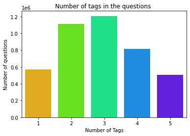

```python
sns.countplot(df_no_dup.tag_count, palette='gist_rainbow')
plt.title("Number of tags in the questions ")
plt.xlabel("Number of Tags")
plt.ylabel("Number of questions")
plt.show()
```

### 3.2 Analysis of tags

**Calculating the tags count for the entire train data:**

```python
tag_data = df_no_dup.Tags
tag_data[tag_data.isnull()] = 'NaN'
vectorizer = CountVectorizer(tokenizer = lambda x: x.split())
tag_dtm = vectorizer.fit_transform(tag_data.values)
tags = vectorizer.get_feature_names()
print("There are total", tag_dtm.shape[1], "unique tags")
```

```
There are total 42048 unique tags
```

```python
freqs = tag_dtm.sum(axis=0).A1
result = dict(zip(tags, freqs))
```

```python
tag_df = pd.DataFrame(result.items(), columns=['Tags', 'Counts'])
tag_df.head()
```

|  | Tags | Counts |
| --- | --- | --- |
| 0 | .a | 18 |
| 1 | .app | 37 |
| 2 | .asp.net-mvc | 1 |
| 3 | .aspxauth | 21 |
| 4 | .bash-profile | 138 |

```python
tag_df_sorted = tag_df.sort_values(['Counts'], ascending=False)
tag_counts = tag_df_sorted.Counts.values
```

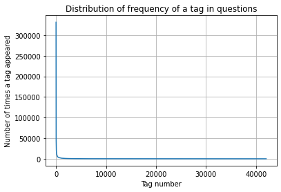

```python
plt.plot(tag_counts)
plt.title("Distribution of frequency of a tag in questions")
plt.grid()
plt.xlabel("Tag number")
plt.ylabel("Number of times a tag appeared")
plt.show()
```

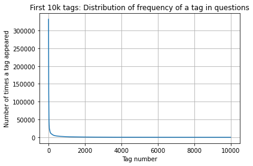

```python
plt.plot(tag_counts[0:10000])
plt.title("First 10k tags: Distribution of frequency of a tag in questions")
plt.grid()
plt.xlabel("Tag number")
plt.ylabel("Number of times a tag appeared")
plt.show()
```

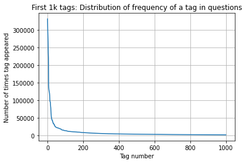

```python
plt.plot(tag_counts[0:1000])
plt.title('First 1k tags: Distribution of frequency of a tag in questions')
plt.grid()
plt.xlabel("Tag number")
plt.ylabel("Number of times tag appeared")
plt.show()
```

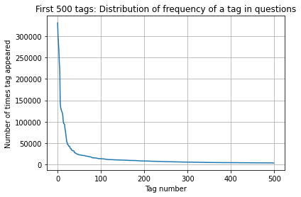

```python
plt.plot(tag_counts[0:500])
plt.title('First 500 tags: Distribution of frequency of a tag in questions')
plt.grid()
plt.xlabel("Tag number")
plt.ylabel("Number of times tag appeared")
plt.show()
```

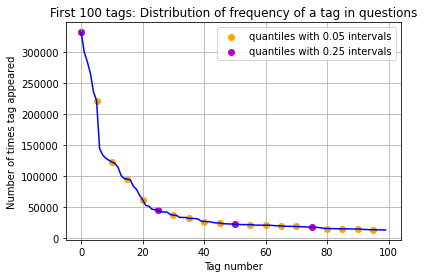

```python
plt.plot(tag_counts[0:100], c='b')
plt.scatter(x=list(range(0,100,5)), y=tag_counts[0:100:5], c='orange', label="quantiles with 0.05 intervals")
plt.scatter(x=list(range(0,100,25)), y=tag_counts[0:100:25], c='m', label="quantiles with 0.25 intervals")
plt.title('First 100 tags: Distribution of frequency of a tag in questions')
plt.grid()
plt.xlabel("Tag number")
plt.ylabel("Number of times tag appeared")
plt.legend()
plt.show()
```

**Generating WordCloud for unique tags based on their frequencies:**

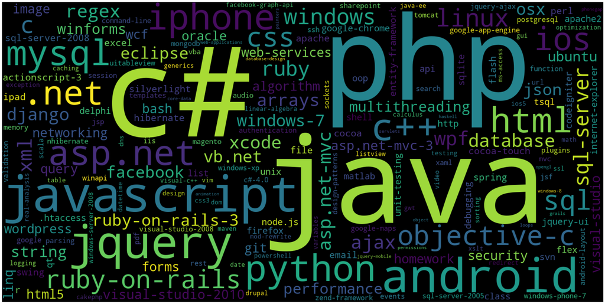

```python
tup = dict(result.items())
wordcloud = WordCloud(width=1600, height=800).generate_from_frequencies(tup)
fig = plt.figure(figsize=(30, 20))
plt.imshow(wordcloud)
plt.axis('off')
plt.tight_layout()
plt.show()
```

[figure not shown]

```python
i = np.arange(30)
tag_df_sorted.head(30).plot(kind='bar')
plt.title('Frequency of top 20 tags')
plt.xticks(i, tag_df_sorted['Tags'])
plt.xlabel('Tags')
plt.ylabel('Frequency')
plt.show()
```

Due to computational limitations we will use only 500000 data samples out of total 4206314 samples, which is roughly 12% of the total data

```python
data = df_no_dup.sample(n=500000)
data.to_csv('data.csv', index=False)
```

## 4. Machine Learning Models

### 4.1 Applying Logistic Regression (using SGD Classifier and non-weighted data points) with OneVsRest Classifier

#### 4.1.1 Loading the data

```python
data = pd.read_csv('data.csv')
print('The shape of loaded data is', data.shape)
data.head()
```

```
The shape of loaded data is (500000, 5)
```

|  | Id | Title | Body | Tags | tag_count |
| --- | --- | --- | --- | --- | --- |
| 0 | 5415413 | google maps to display friendly inline error | <p>The main problem here is when license key i... | javascript google google-maps-api-3 popup maps | 5 |
| 1 | 1524054 | Does NSWindow have IBAction | <p>In subview of ViewController, we can specif... | objective-c xcode4 | 2 |
| 2 | 1966248 | How do you add a new class to first child of <... | <p>I am generating a style listing dynamically... | jquery css | 2 |
| 3 | 1970051 | How can I parse JSON? | <blockquote>\n <p><strong>Possible Duplicate:... | jquery json parsing | 3 |
| 4 | 4919298 | Script creating a redirect warning | <p>I am working on my first site using google ... | google-apps-script google-sites | 2 |

#### 4.1.2 Cleaning and preprocessing of questions

1. Sample 500k data points
2. Separate out code-snippets from Body
3. Remove Spcial characters from Question title and description (not in code)
4. Remove stop words (Except 'C')
5. Remove HTML Tags
6. Convert all the characters into small letters
7. Use SnowballStemmer to stem the words

```python
def striphtml(data):
    cleanr = re.compile('<.*?>')
    cleantext = re.sub(cleanr, ' ', str(data))
    return cleantext

stop_words = set(stopwords.words('english'))
stemmer = SnowballStemmer("english")
```

```python
len_pre = 0
len_post = 0
preprocessed_questions = []
for index, row in tqdm(data.iterrows()):

    title = row['Title']
    question = row['Body']
    len_pre += (len(question)+len(title))

    question = re.sub('<code>(.*?)</code>', '', str(question), flags=re.MULTILINE|re.DOTALL)
    question = striphtml(question)
    title = title.encode('utf-8')

    question = str(title) + " " + str(question)
    question = re.sub(r'[^A-Za-z]+', ' ', question)
    words = word_tokenize(str(question.lower()))
    question = ' '.join(str(stemmer.stem(j)) for j in words if j not in stop_words and (len(j)!=1 or j=='c'))
    len_post += len(question)
    preprocessed_questions.append(question)

data['Question'] = preprocessed_questions
avg_len_pre = (len_pre*1.0)/(data.shape[0])
avg_len_post = (len_post*1.0)/(data.shape[0])
print('-' * 60)
print( "Average length of questions before preprocessing: %d" %avg_len_pre)
print( "Average length of questions after preprocessing: %d" %avg_len_post)
```

```
500000it [12:08, 686.39it/s]
```

```
------------------------------------------------------------
Average length of questions before preprocessing: 1169
Average length of questions after preprocessing: 324
```

**Sample data after preprocessing**

```python
for question in data['Question'].head().values:
  print('='*80)
  print(question)
```

```
================================================================================
googl map display friend inlin error main problem licens key invalid googl map api return annoy javascript popup alert box sinc deploy multipl user user need regist googl map licens way detect annoy popup messag chang friend inlin div
================================================================================
nswindow ibact subview viewcontrol specifi form would form load etc nswindow object look like everi time drag drop thing pull outlet usual creat ibact drag drop assist editor
================================================================================
add new class first child ul jqueri generat style list dynam jqueri function add class first use jqueri
================================================================================
pars json possibl duplic pars json jqueri tri pars follow json file need get thumb id json file know pars follow json use jqueri javascript
================================================================================
script creat redirect warn work first site use googl script script embed creat ui refer googl spreadsheet link page site whenev link click get interim page say previous page send https site googl com site gchromeat xxxx want visit page return previous page way get around behavior replic https site g…
```

```python
preprocessed_data = data.drop(['Id', 'Title', 'Body', 'tag_count'], axis=1)
preprocessed_data.Tags.fillna(' ', inplace=True)
preprocessed_data.reset_index(inplace=True, drop='index')
print('The final shape of preprocessed data is', preprocessed_data.shape)
preprocessed_data.head()
```

```
The final shape of preprocessed data is (500000, 2)
```

|  | Tags | Question |
| --- | --- | --- |
| 0 | javascript google google-maps-api-3 popup maps | googl map display friend inlin error main prob... |
| 1 | objective-c xcode4 | nswindow ibact subview viewcontrol specifi for... |
| 2 | jquery css | add new class first child ul jqueri generat st... |
| 3 | jquery json parsing | pars json possibl duplic pars json jqueri tri ... |
| 4 | google-apps-script google-sites | script creat redirect warn work first site use... |

#### 4.1.3 Converting tags for multilabel problems

```python
vectorizer = CountVectorizer(tokenizer=lambda x: x.split(), binary='true')
multilabel_y = vectorizer.fit_transform(preprocessed_data['Tags'])
```

```python
def tags_to_choose(n):
    t = multilabel_y.sum(axis=0).tolist()[0]
    sorted_tags_i = sorted(range(len(t)), key=lambda i: t[i], reverse=True)
    multilabel_yn = multilabel_y[:,sorted_tags_i[:n]]
    return multilabel_yn

def questions_explained_fn(n):
    multilabel_yn = tags_to_choose(n)
    x = multilabel_yn.sum(axis=1)
    return (np.count_nonzero(x==0))
```

```python
questions_explained = []
total_tags = multilabel_y.shape[1]
total_qs = preprocessed_data.shape[0]
for i in range(500, total_tags, 100):
    questions_explained.append(np.round(((total_qs-questions_explained_fn(i))/total_qs)*100, 3))
```

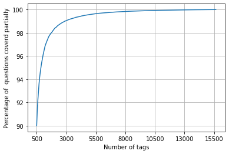

```
By using 500 tags we are covering  89.998 % of questions
```

```python
fig, ax = plt.subplots()
ax.plot(questions_explained)
xlabel = list(500+np.array(range(-50,450,50))*50)
ax.set_xticklabels(xlabel)
plt.xlabel("Number of tags")
plt.ylabel("Percentage of  questions coverd partially")
plt.grid()
plt.show()
print("By using", 500, "tags we are covering ", questions_explained[0], "% of questions")
```

```python
multilabel_yx = tags_to_choose(500)
print("Number of questions that are not covered:", questions_explained_fn(500), "out of ", total_qs)
```

```
Number of questions that are not covered: 50008 out of  500000
```

```python
print("Number of tags in sample:", multilabel_y.shape[1])
print("number of tags taken:", multilabel_yx.shape[1], "(", (multilabel_yx.shape[1]/multilabel_y.shape[1])*100, "%)")
```

```
Number of tags in sample: 30831
number of tags taken: 500 ( 1.6217443482209464 %)
```

#### 4.1.4 Split the data into train and test (80:20)

```python
total_size = preprocessed_data.shape[0]
train_size = int(0.80*total_size)

x_train = preprocessed_data.head(train_size)
x_test = preprocessed_data.tail(total_size - train_size)

y_train = multilabel_yx[0:train_size, :]
y_test = multilabel_yx[train_size:total_size, :]
```

```python
print("Shape of train data:", y_train.shape)
print("Shape of test data:", y_test.shape)
```

```
Shape of train data: (400000, 500)
Shape of test data: (100000, 500)
```

#### 4.1.5 Featurizing the data with Tfidf vectorizer

```python
vectorizer = TfidfVectorizer(tokenizer=lambda x: x.split(), min_df=0.00009, ngram_range=(1, 3))
x_train_multilabel = vectorizer.fit_transform(x_train['Question'])
x_test_multilabel = vectorizer.transform(x_test['Question'])
```

```python
print("Shape of train data X:", x_train_multilabel.shape, "Y:", y_train.shape)
print("Shape of test data X:", x_test_multilabel.shape, "Y:", y_test.shape)
```

```
Shape of train data X: (400000, 89190) Y: (400000, 500)
Shape of test data X: (100000, 89190) Y: (100000, 500)
```

#### 4.1.6 Applying Logistic Regression model

```python
classifier = OneVsRestClassifier(SGDClassifier(loss='log', alpha=0.00001, penalty='l1'), n_jobs=-1)
classifier.fit(x_train_multilabel, y_train)
predictions = classifier.predict(x_test_multilabel)

print("Accuracy:", metrics.accuracy_score(y_test, predictions))

precision = metrics.precision_score(y_test, predictions, average='micro')
recall = metrics.recall_score(y_test, predictions, average='micro')
f1 = metrics.f1_score(y_test, predictions, average='micro')

print("Micro-average quality numbers:")
print("Precision: {:.4f}  Recall: {:.4f}  F1-measure: {:.4f}".format(precision, recall, f1))

print('='*80)
print('The classification report for the 500 output labels is as follows:\n')
print(metrics.classification_report(y_test, predictions))
```

```
Accuracy: 0.22073
Micro-average quality numbers:
Precision: 0.7133  Recall: 0.3308  F1-measure: 0.4520
================================================================================
The classification report for the 500 output labels is as follows:

              precision    recall  f1-score   support

           0       0.63      0.23      0.34      7894
           1       0.78      0.44      0.56      7019
           2       0.83      0.55      0.66      6756
           3       0.76      0.42      0.54      6324
           4       0.94      0.77      0.85      5632
           5       0.86      0.65      0.74      5350
           6       0.72      0.32      0.44      3541
```

[output cut: 498 more lines]

### 4.2 Applying Logistic Regression (using SGD Classifier and weighted data points) with OneVsRest Classifier

#### 4.2.1 Loading the data

```python
data = pd.read_csv('data.csv')
print('The shape of loaded data is', data.shape)
data.head()
```

```
The shape of loaded data is (500000, 5)
```

|  | Id | Title | Body | Tags | tag_count |
| --- | --- | --- | --- | --- | --- |
| 0 | 5415413 | google maps to display friendly inline error | <p>The main problem here is when license key i... | javascript google google-maps-api-3 popup maps | 5 |
| 1 | 1524054 | Does NSWindow have IBAction | <p>In subview of ViewController, we can specif... | objective-c xcode4 | 2 |
| 2 | 1966248 | How do you add a new class to first child of <... | <p>I am generating a style listing dynamically... | jquery css | 2 |
| 3 | 1970051 | How can I parse JSON? | <blockquote>\n <p><strong>Possible Duplicate:... | jquery json parsing | 3 |
| 4 | 4919298 | Script creating a redirect warning | <p>I am working on my first site using google ... | google-apps-script google-sites | 2 |

#### 4.2.2 Cleaning and preprocessing of questions

1. Separate Code from Body
2. Remove Spcial characters from Question title and description (not in code)
3. Give more weightage to title : Add title three times to the question
4. Remove stop words (Except 'C')
5. Remove HTML Tags
6. Convert all the characters into small letters
7. Use SnowballStemmer to stem the words

```python
def striphtml(data):
    cleanr = re.compile('<.*?>')
    cleantext = re.sub(cleanr, ' ', str(data))
    return cleantext

stop_words = set(stopwords.words('english'))
stemmer = SnowballStemmer("english")
```

```python
questions_with_code = 0
len_pre = 0
len_post = 0
preprocessed_questions = []
for index, row in tqdm(data.iterrows()):

    title = row['Title']
    question = row['Body']
    len_pre += (len(question)+len(title))

    question = re.sub('<code>(.*?)</code>', '', str(question), flags=re.MULTILINE|re.DOTALL)
    question = striphtml(question)
    title = title.encode('utf-8')

    question = str(title)+" "+str(title)+" "+str(title)+" "+str(question)
    question = re.sub(r'[^A-Za-z]+', ' ', question)
    words = word_tokenize(str(question.lower()))
    question = ' '.join(str(stemmer.stem(j)) for j in words if j not in stop_words and (len(j)!=1 or j=='c'))
    len_post += len(question)
    preprocessed_questions.append(question)

data['Question'] = preprocessed_questions
avg_len_pre = (len_pre*1.0)/(data.shape[0])
avg_len_post = (len_post*1.0)/(data.shape[0])
print('-' * 60)
print( "Average length of questions before preprocessing: %d" %avg_len_pre)
print( "Average length of questions after preprocessing: %d" %avg_len_post)
```

```
500000it [13:42, 607.58it/s]
```

```
------------------------------------------------------------
Average length of questions before preprocessing: 1169
Average length of questions after preprocessing: 395
```

**Sample data after preprocessing**

```python
for question in data['Question'].head().values:
  print('='*80)
  print(question)
```

```
================================================================================
googl map display friend inlin error googl map display friend inlin error googl map display friend inlin error main problem licens key invalid googl map api return annoy javascript popup alert box sinc deploy multipl user user need regist googl map licens way detect annoy popup messag chang friend i…
================================================================================
nswindow ibact nswindow ibact nswindow ibact subview viewcontrol specifi form would form load etc nswindow object look like everi time drag drop thing pull outlet usual creat ibact drag drop assist editor
================================================================================
add new class first child ul jqueri add new class first child ul jqueri add new class first child ul jqueri generat style list dynam jqueri function add class first use jqueri
================================================================================
pars json pars json pars json possibl duplic pars json jqueri tri pars follow json file need get thumb id json file know pars follow json use jqueri javascript
================================================================================
script creat redirect warn script creat redirect warn script creat redirect warn work first site use googl script script embed creat ui refer googl spreadsheet link page site whenev link click get interim page say previous page send https site googl com site gchromeat xxxx want visit page return pre…
```

```python
preprocessed_data = data.drop(['Id', 'Title', 'Body', 'tag_count'], axis=1)
preprocessed_data.Tags.fillna(' ', inplace=True)
preprocessed_data.reset_index(inplace=True, drop='index')
print('The final shape of preprocessed data is', preprocessed_data.shape)
preprocessed_data.head()
```

```
The final shape of preprocessed data is (500000, 2)
```

|  | Tags | Question |
| --- | --- | --- |
| 0 | javascript google google-maps-api-3 popup maps | googl map display friend inlin error googl map... |
| 1 | objective-c xcode4 | nswindow ibact nswindow ibact nswindow ibact s... |
| 2 | jquery css | add new class first child ul jqueri add new cl... |
| 3 | jquery json parsing | pars json pars json pars json possibl duplic p... |
| 4 | google-apps-script google-sites | script creat redirect warn script creat redire... |

#### 4.2.3 Converting tags for multilabel problems

```python
vectorizer = CountVectorizer(tokenizer=lambda x: x.split(), binary='true')
multilabel_y = vectorizer.fit_transform(preprocessed_data['Tags'])
```

```python
def tags_to_choose(n):
    t = multilabel_y.sum(axis=0).tolist()[0]
    sorted_tags_i = sorted(range(len(t)), key=lambda i: t[i], reverse=True)
    multilabel_yn = multilabel_y[:,sorted_tags_i[:n]]
    return multilabel_yn

def questions_explained_fn(n):
    multilabel_yn = tags_to_choose(n)
    x = multilabel_yn.sum(axis=1)
    return (np.count_nonzero(x==0))
```

```python
questions_explained = []
total_tags = multilabel_y.shape[1]
total_qs = preprocessed_data.shape[0]
for i in range(500, total_tags, 100):
    questions_explained.append(np.round(((total_qs-questions_explained_fn(i))/total_qs)*100, 3))
```

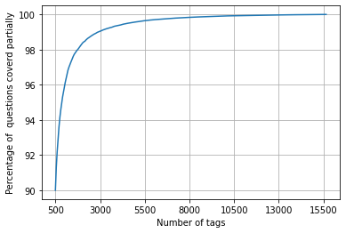

```
By using 500 tags we are covering  89.998 % of questions
```

```python
fig, ax = plt.subplots()
ax.plot(questions_explained)
xlabel = list(500+np.array(range(-50,450,50))*50)
ax.set_xticklabels(xlabel)
plt.xlabel("Number of tags")
plt.ylabel("Percentage of  questions coverd partially")
plt.grid()
plt.show()
print("By using", 500, "tags we are covering ", questions_explained[0], "% of questions")
```

```python
multilabel_yx = tags_to_choose(500)
print("Number of questions that are not covered :", questions_explained_fn(500), "out of ", total_qs)
```

```
Number of questions that are not covered : 50008 out of  500000
```

```python
print("Number of tags in sample :", multilabel_y.shape[1])
print("number of tags taken :", multilabel_yx.shape[1], "(" ,(multilabel_yx.shape[1]/multilabel_y.shape[1])*100, "%)")
```

```
Number of tags in sample : 30831
number of tags taken : 500 ( 1.6217443482209464 %)
```

#### 4.2.4 Split the data into train and test (80:20)

```python
total_size = preprocessed_data.shape[0]
train_size = int(0.80*total_size)

x_train = preprocessed_data.head(train_size)
x_test = preprocessed_data.tail(total_size - train_size)

y_train = multilabel_yx[0:train_size, :]
y_test = multilabel_yx[train_size:total_size, :]
```

```python
print("Shape of train data :", y_train.shape)
print("Shape of test data :", y_test.shape)
```

```
Shape of train data : (400000, 500)
Shape of test data : (100000, 500)
```

#### 4.2.5 Featurizing the data with Tfidf vectorizer

```python
vectorizer = TfidfVectorizer(tokenizer=lambda x: x.split(), min_df=0.00009, ngram_range=(1, 3))
x_train_multilabel = vectorizer.fit_transform(x_train['Question'])
x_test_multilabel = vectorizer.transform(x_test['Question'])
```

```python
print("Shape of train data X:", x_train_multilabel.shape, "Y:", y_train.shape)
print("Shape of test data X:", x_test_multilabel.shape, "Y:", y_test.shape)
```

```
Shape of train data X: (400000, 90833) Y: (400000, 500)
Shape of test data X: (100000, 90833) Y: (100000, 500)
```

#### 4.2.6 Applying Logistic Regression model

```python
classifier = OneVsRestClassifier(SGDClassifier(loss='log', alpha=0.00001, penalty='l1'), n_jobs=-1)
classifier.fit(x_train_multilabel, y_train)
predictions = classifier.predict(x_test_multilabel)

print("Accuracy:" , metrics.accuracy_score(y_test, predictions))

precision = metrics.precision_score(y_test, predictions, average='micro')
recall = metrics.recall_score(y_test, predictions, average='micro')
f1 = metrics.f1_score(y_test, predictions, average='micro')

print("Micro-average quality numbers:")
print("Precision: {:.4f}  Recall: {:.4f}  F1-measure: {:.4f}".format(precision, recall, f1))

print('='*80)
print('The classification report for the 500 output labels is as follows:\n')
print(metrics.classification_report(y_test, predictions))
```

```
Accuracy: 0.23479
Micro-average quality numbers:
Precision: 0.7293  Recall: 0.3516  F1-measure: 0.4745
================================================================================
The classification report for the 500 output labels is as follows:

              precision    recall  f1-score   support

           0       0.64      0.25      0.36      7894
           1       0.81      0.46      0.58      7019
           2       0.86      0.56      0.67      6756
           3       0.78      0.43      0.55      6324
           4       0.95      0.76      0.85      5632
           5       0.87      0.64      0.74      5350
           6       0.73      0.32      0.45      3541
```

[output cut: 498 more lines]

### 4.3 Hyperparameter tuning on alpha for Logistic regression using GridSearch

```python
parameters  = {
    "estimator__alpha": [10 ** x for x in range(-7, -3)]
    }

classifier = OneVsRestClassifier(SGDClassifier(loss='log', penalty='l1'))
model = GridSearchCV(classifier, param_grid=parameters, scoring='f1_micro', cv=3, n_jobs=-1, verbose=50)
model.fit(x_train_multilabel, y_train)
```

```
Fitting 3 folds for each of 4 candidates, totalling 12 fits
[Parallel(n_jobs=-1)]: Using backend LokyBackend with 2 concurrent workers.
[Parallel(n_jobs=-1)]: Done   1 tasks      | elapsed: 33.6min
[Parallel(n_jobs=-1)]: Done   2 tasks      | elapsed: 33.7min
[Parallel(n_jobs=-1)]: Done   3 tasks      | elapsed: 61.5min
[Parallel(n_jobs=-1)]: Done   4 tasks      | elapsed: 67.3min
[Parallel(n_jobs=-1)]: Done   5 tasks      | elapsed: 89.4min
[Parallel(n_jobs=-1)]: Done   6 tasks      | elapsed: 95.0min
[Parallel(n_jobs=-1)]: Done   7 tasks      | elapsed: 113.0min
[Parallel(n_jobs=-1)]: Done   8 tasks      | elapsed: 118.8min
[Parallel(n_jobs=-1)]: Done   9 tasks      | elapsed: 136.6min
[Parallel(n_jobs=-1)]: Done  10 out of  12 | elapsed: 144.5min remaining: 28.9min
[Parallel(n_jobs=-1)]: Done  12 out of  12 | elapsed: 167.0min remaining:    0.0s
[Parallel(n_jobs=-1)]: Done  12 out of  12 | elapsed: 167.0min finished
```

```
GridSearchCV(cv=3, error_score=nan,
             estimator=OneVsRestClassifier(estimator=SGDClassifier(alpha=0.0001,
                                                                   average=False,
                                                                   class_weight=None,
                                                                   early_stopping=False,
                                                                   epsilon=0.1,
                                                                   eta0=0.0,
                                                                   fit_intercept=True,
                                                                   l1_ratio=0.15,
                                                                   learning_rate='optimal',
                                                                   loss='log',
                                                                   max_iter=1000,
                                                                   n_iter_no_change=5,
                                                                   n_jobs=None,
                                                                   penalty='l1',
                                                                   power_t=0.5,
                                                                   random_state=None,
                                                                   shuffle=True,
                                                                   tol=0.001,
                                                                   validation_fraction=0.1,
                                                                   verbose=0,
                                                                   warm_start=False),
                                           n_jobs=None),
             iid='deprecated', n_jobs=-1,
             param_grid={'estimator__alpha': [1e-07, 1e-06, 1e-05, 0.0001]},
             pre_dispatch='2*n_jobs', refit=True, return_train_score=False,
             scoring='f1_micro', verbose=50)
```

```python
print('The best value of alpha is', model.best_params_['estimator__alpha'])
```

```
The best value of alpha is 1e-06
```

```python
predictions = model.predict(x_test_multilabel)

print("Accuracy:" , metrics.accuracy_score(y_test, predictions))

precision = metrics.precision_score(y_test, predictions, average='micro')
recall = metrics.recall_score(y_test, predictions, average='micro')
f1 = metrics.f1_score(y_test, predictions, average='micro')

print("Micro-average quality numbers:")
print("Precision: {:.4f}  Recall: {:.4f}  F1-measure: {:.4f}".format(precision, recall, f1))

print('='*80)
print('The classification report for the 500 output labels is as follows:\n')
print(metrics.classification_report(y_test, predictions))
```

```
Accuracy: 0.24889
Micro-average quality numbers:
Precision: 0.7000  Recall: 0.4105  F1-measure: 0.5175
================================================================================
The classification report for the 500 output labels is as follows:

              precision    recall  f1-score   support

           0       0.63      0.37      0.46      7894
           1       0.77      0.53      0.62      7019
           2       0.83      0.61      0.70      6756
           3       0.73      0.50      0.59      6324
           4       0.94      0.84      0.89      5632
           5       0.86      0.68      0.76      5350
           6       0.70      0.44      0.54      3541
```

[output cut: 498 more lines]

### 4.4 Using OneVsRestClassifier with Linear-SVM (SGDClassifier with loss-hinge)

```python
classifier = OneVsRestClassifier(SGDClassifier(loss='hinge', alpha=0.00001, penalty='l1'), n_jobs=-1)
classifier.fit(x_train_multilabel, y_train)
predictions = classifier.predict(x_test_multilabel)

print("Accuracy:" , metrics.accuracy_score(y_test, predictions))

precision = metrics.precision_score(y_test, predictions, average='micro')
recall = metrics.recall_score(y_test, predictions, average='micro')
f1 = metrics.f1_score(y_test, predictions, average='micro')

print("Micro-average quality numbers:")
print("Precision: {:.4f}  Recall: {:.4f}  F1-measure: {:.4f}".format(precision, recall, f1))

print('='*80)
print('The classification report for the 500 output labels is as follows:\n')
print(metrics.classification_report(y_test, predictions))
```

```
Accuracy: 0.24792
Micro-average quality numbers:
Precision: 0.8145  Recall: 0.3208  F1-measure: 0.4603
================================================================================
The classification report for the 500 output labels is as follows:

              precision    recall  f1-score   support

           0       0.69      0.15      0.24      7894
           1       0.83      0.45      0.59      7019
           2       0.86      0.56      0.68      6756
           3       0.84      0.38      0.53      6324
           4       0.95      0.79      0.86      5632
           5       0.88      0.63      0.74      5350
           6       0.82      0.21      0.34      3541
```

[output cut: 498 more lines]

# 5. Comparison of various ML models

```python
p = PrettyTable()
p.field_names = ['Model', 'N-gram range', 'Accuracy', 'micro-f1 score']
p.add_row(['LR using SGD (non-weighted)', '(1, 3)', '0.22073', '0.4520'])
p.add_row(['LR using SGD (weighted)', '(1, 3)', '0.23479', '0.4745'])
p.add_row(['LR using SGD (tuned alpha)', '(1, 3)', '0.24889', '0.5175'])
p.add_row(['SVM using SGD (weighted)', '(1, 3)', '0.24792', '0.4603'])
print(p)
```

```
+-----------------------------+--------------+----------+----------------+
|            Model            | N-gram range | Accuracy | micro-f1 score |
+-----------------------------+--------------+----------+----------------+
| LR using SGD (non-weighted) |    (1, 3)    | 0.22073  |     0.4520     |
|   LR using SGD (weighted)   |    (1, 3)    | 0.23479  |     0.4745     |
|  LR using SGD (tuned alpha) |    (1, 3)    | 0.24889  |     0.5175     |
|   SVM using SGD (weighted)  |    (1, 3)    | 0.24792  |     0.4603     |
+-----------------------------+--------------+----------+----------------+
```